# Ejercicios 31/01/22

Introducción a la Biolgía de Sistemas

Luis Andrés Rojas García Exp. 279465

03 febrero, 2022

### Ejercicio 4.1

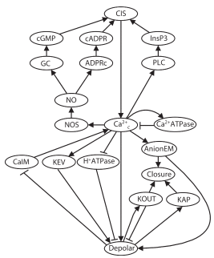

Figura 4.3

1. ¿La red está fuertemente conectada? Explica tu respuesta. No está fuertemente conectada porque tiene una densidad de conexiones del 8%, tiene solamente el 8% de conexiones que pudiera tener la red completa.

   $$\begin{array}{l}
   = n(n-1) \\
   = 19(19-1) \\
   = 19(18) = 342 \\
   \\
   D = \frac{\#edges}{n(n-1)} \\
   D = \frac{28}{342} \\
   D = 0.081 * 100 \% = 8\%
   \end{array}$$
2. Si la red no está fuertemente conectada, identifique sus componentes fuertemente conectados.

   El Ca$^{2+}$ con la Ca$^{2+}$ATPase, ya que tiene el total de conexiones que pudiera tener un subgrafo de dos nodos.
   $$\begin{array}{l}
   = n(n-1) \\
   = 2(2-1) \\
   = 2(1) = 2 \\
   \\
   D = \frac{\#edges}{n(n-1)} \\
   D = \frac{2}{2} \\
   D = 1 * 100\% = 100\%
   \end{array}$$

   También está Ca$^{2+}$ con Depolar y AnionEM, que tienen el 50% de conexiones para el subgrafo de 3 nodos.
   $$\begin{array}{l}
   = n(n-1) \\
   = 3(3-1) \\
   = 3(2) = 6 \\
   \\
   D = \frac{\#edges}{n(n-1)} \\
   D = \frac{3}{6} \\
   D = 0.5 * 100\% = 50\%
   \end{array}$$
3. ¿La red contiene bucles? Si es así, identifíquelos.

   Todas las conexiones que llegan al nodo de closure.
4. ¿La red contiene ciclos? Si es así, identifique todos los ciclos.
   - El ciclo de activación entre Ca$^{2+}$ - PLC - InsP3 - CIS
   - El ciclo de activación de Ca$^{2+}$ hacia NOS, que a final de cuentas, va a terminar activando Ca$^{2+}$.
5. ¿Existen bucles de realimentación? Si es así, identifíquelos como positivos, negativos o incoherentes.
6. ¿Hay circuitos de retroalimentación? Identifícalos. Identifica su signo como positivo o negativo.

### Ejercicio 4.2

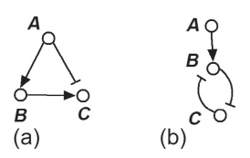

1. Construya la función de transición y la tabla de verdad para las redes de la figura 4.5. Considere las posibilidades AND y OR para la función de transición de C para la red en la Figura 4.5a y para la función de transición del nodo B para la red en la Figura 4.5b

##### Figura 4.5 (a)

```
    targets, factors
    A, 1
    B, A
    C, B | !A
```

```r
library(BoolNet)
net1 <- loadNetwork("Redes/ejercicios_redes_4.5(a).txt")
net1
```

```
## Boolean network with 3 genes
##
## Involved genes:
## A B C
##
## Transition functions:
## A = 1
## B = A
## C = B | !A
##
## Knocked-out and over-expressed genes:
## A = 1
```

```r
getAttractors(net1)
```

```
## Attractor 1 is a simple attractor consisting of 1 state(s) and has a basin of 4 state(s):
##
##  |--<--|
##  V     |
##  111   |
##  V     |
##  |-->--|
##
##
## Genes are encoded in the following order: A B C
```

[output not shown]

[output not shown]

##### Figura 4.5 (b)

```
    targets, factors
    A, 1
    B, A & !C
    C, !B
```

```r
net2 <- loadNetwork("Redes/ejercicios_redes_4.5b.txt")
net2
```

```
## Boolean network with 3 genes
##
## Involved genes:
## A B C
##
## Transition functions:
## A = 1
## B = A & !C
## C = !B
##
## Knocked-out and over-expressed genes:
## A = 1
```

```r
getAttractors(net2)
```

```
## Attractor 1 is a simple attractor consisting of 1 state(s) and has a basin of 1 state(s):
##
##  |--<--|
##  V     |
##  110   |
##  V     |
##  |-->--|
##
##
## Genes are encoded in the following order: A B C
##
## Attractor 2 is a simple attractor consisting of 1 state(s) and has a basin of 1 state(s):
##
##  |--<--|
##  V     |
##  101   |
##  V     |
##  |-->--|
##
##
## Genes are encoded in the following order: A B C
##
## Attractor 3 is a simple attractor consisting of 2 state(s) and has a basin of 2 state(s):
##
##  |--<--|
##  V     |
##  100   |
##  111   |
##  V     |
##  |-->--|
##
##
## Genes are encoded in the following order: A B C
```

[output not shown]

[output not shown]

### Ejercicio 4.3

Muestre que la tabla de verdad de una función booleana con k variables tiene 2k filas y k + 1 columnas. Sugerencia: determine el número de secuencias diferentes de longitud k que se pueden formar a partir de 0 y 1.

Porque existe una columna para cada variable involucrada en la función booleanaa, y una columna para el resultado de la función. En los renglones, existen el doble de las variables involucradas porque se consideran todos los posibles estados, y los estados de una red booleana se determinan por $2^{\#\text{no. de nodos}}$

### Ejericio 4.4

¿Puede adivinar el(los) atractor(es) del modelo booleano en el Ejemplo 4.1? Considere los casos xA = 0 y xA = 1 por separado.

No había Ejemplo 4.1 Roberto

### Ejercicio 4.5

Determine el gráfico de transición de estado del modelo en la Figura 4.4 en presencia de una señal (xA = 1) cuando se utiliza la actualización síncrona. Compare con la Figura 4.6a (panel derecho)

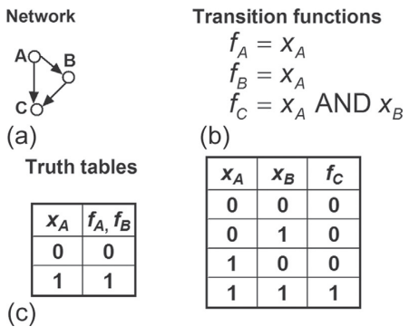

Figura 4.4

```
targets, factors
A, A
B, A
C, A & B
```

```r
net5 <- loadNetwork("Redes/ejercicio_red_4.4.txt")
net5
```

```
## Boolean network with 3 genes
##
## Involved genes:
## A B C
##
## Transition functions:
## A = A
## B = A
## C = A & B
```

```r
attractors_net5 <- getAttractors(net5)
attractors_net5
```

```
## Attractor 1 is a simple attractor consisting of 1 state(s) and has a basin of 4 state(s):
##
##  |--<--|
##  V     |
##  000   |
##  V     |
##  |-->--|
##
##
## Genes are encoded in the following order: A B C
##
## Attractor 2 is a simple attractor consisting of 1 state(s) and has a basin of 4 state(s):
##
##  |--<--|
##  V     |
##  111   |
##  V     |
##  |-->--|
##
##
## Genes are encoded in the following order: A B C
```

```r
getTransitionTable(attractors_net5)
```

```
##   State     Next state  Attr. basin  # trans. to attr.
##     000 =>         000            1                  0
##     100 =>         110            2                  2
##     010 =>         000            1                  1
##     110 =>         111            2                  1
##     001 =>         000            1                  1
##     101 =>         110            2                  2
##     011 =>         000            1                  1
##     111 =>         111            2                  0
##
## Genes are encoded in the following order: A B C
```

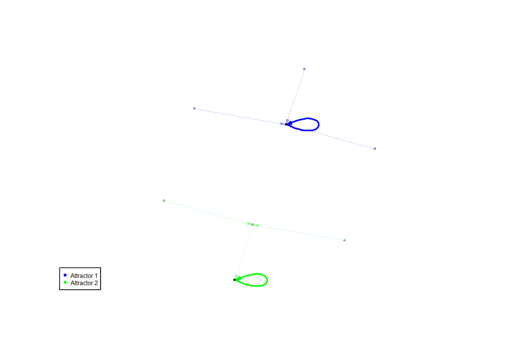

```r
plotStateGraph(attractors_net5)
```

### Ejercicio 4.6

Consideremos nuevamente la red de la figura 4.4 con ausencia de señal (xA = 0) pero usa la actualización asincrónica general, cuando un nodo se actualiza en cualquier paso de tiempo dado

```
targets, factors
A, 0
B, A
C, A & B
```

```r
net6 <- loadNetwork("Redes/ejercicio_red_4.4_a_0.txt")
net6
```

```
## Boolean network with 3 genes
##
## Involved genes:
## A B C
##
## Transition functions:
## A = 0
## B = A
## C = A & B
##
## Knocked-out and over-expressed genes:
## A = 0
```

```r
attractors_net6 <- getAttractors(net6, type = "asynchronous", startStates=4)
attractors_net6
```

```
## Attractor 1 is a simple attractor consisting of 1 state(s):
##
##  |--<--|
##  V     |
##  000   |
##  V     |
##  |-->--|
##
##
## Genes are encoded in the following order: A B C
```

### Ejercicio 4.7

Determine el gráfico de transición de estado del modelo en la Figura 4.4 en presencia de señal (xA = 1) cuando se utiliza la actualización asíncrona general. Compare con la Figura 4.6b (panel derecho).

```
targets, factors
A, 1
B, A
C, A & B
```

```r
net7 <- loadNetwork("Redes/ejercicio_red_4.4_a_1.txt")
net7
```

```
## Boolean network with 3 genes
##
## Involved genes:
## A B C
##
## Transition functions:
## A = 1
## B = A
## C = A & B
##
## Knocked-out and over-expressed genes:
## A = 1
```

```r
attractors_net7 <- getAttractors(net7, type = "asynchronous", startStates=4)
attractors_net7
```

```
## Attractor 1 is a simple attractor consisting of 1 state(s):
##
##  |--<--|
##  V     |
##  111   |
##  V     |
##  |-->--|
##
##
## Genes are encoded in the following order: A B C
```

```r
#plotStateGraph(attractors_net7) Este no me salió Roberto, en los argumentos de la función de Boolnet no encontré la forma en que grafique de manera asincrónica.
plotAttractors(attractors_net7, mode="graph")
```

[output not shown]

### Ejercicio 4.8

Determine los gráficos de transición de estado para las redes en la Figura 4.5 cuando use general actualización asíncrona. Considere las posibilidades AND y OR para la función de transición de C para la red en la Figura 4.5a y para la función de transición de B para la red en la Figura 4.5b. Considere tanto el ausencia sostenida (xA = 0) y presencia (xA = 1) del nodo A.

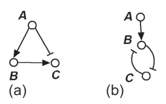

Figura 4.5

##### FIGURA 4.5 A) AND, A = 1

```
targets, factors
A, 1
B, A
C, B & ! A
```

```r
net8 <- loadNetwork("Redes/ejercicio_red_4.5_a_and_a_1.txt")
net8
```

```
## Boolean network with 3 genes
##
## Involved genes:
## A B C
##
## Transition functions:
## A = 1
## B = A
## C = B & ! A
##
## Knocked-out and over-expressed genes:
## A = 1
```

```r
attractors_net8 <- getAttractors(net8, type = "asynchronous", startStates=4)
attractors_net8
```

```
## Attractor 1 is a simple attractor consisting of 1 state(s):
##
##  |--<--|
##  V     |
##  110   |
##  V     |
##  |-->--|
##
##
## Genes are encoded in the following order: A B C
```

```r
BoolNet::plotAttractors(attractors_net8, mode="graph")
```

[output not shown]

##### FIGURA 4.5 A) AND, A = 0

```
targets, factors
A, 0
B, A
C, B & ! A
```

```r
net9 <- loadNetwork("Redes/ejercicio_red_4.5_a_and_a_0.txt")
net9
```

```
## Boolean network with 3 genes
##
## Involved genes:
## A B C
##
## Transition functions:
## A = 0
## B = A
## C = B & ! A
##
## Knocked-out and over-expressed genes:
## A = 0
```

```r
attractors_net9 <- getAttractors(net9, type = "asynchronous", startStates=4)
attractors_net9
```

```
## Attractor 1 is a simple attractor consisting of 1 state(s):
##
##  |--<--|
##  V     |
##  000   |
##  V     |
##  |-->--|
##
##
## Genes are encoded in the following order: A B C
```

```r
BoolNet::plotAttractors(attractors_net9, mode="graph")
```

[output not shown]

##### FIGURA 4.5 A) OR, A = 1

```
targets, factors
A, 1
B, A
C, B | ! A
```

```r
net10 <- loadNetwork("Redes/ejercicio_red_4.5_a_or_a_1.txt")
net10
```

```
## Boolean network with 3 genes
##
## Involved genes:
## A B C
##
## Transition functions:
## A = 1
## B = A
## C = B | ! A
##
## Knocked-out and over-expressed genes:
## A = 1
```

```r
attractors_net10 <- getAttractors(net10, type = "asynchronous", startStates=4)
attractors_net10
```

```
## Attractor 1 is a simple attractor consisting of 1 state(s):
##
##  |--<--|
##  V     |
##  111   |
##  V     |
##  |-->--|
##
##
## Genes are encoded in the following order: A B C
```

```r
BoolNet::plotAttractors(attractors_net10, mode="graph")
```

[output not shown]

##### FIGURA 4.5 A) OR, A = 0

```
targets, factors
A, 0
B, A
C, B | ! A
```

```r
net11 <- loadNetwork("Redes/ejercicio_red_4.5_a_or_a_0.txt")
net11
```

```
## Boolean network with 3 genes
##
## Involved genes:
## A B C
##
## Transition functions:
## A = 0
## B = A
## C = B | ! A
##
## Knocked-out and over-expressed genes:
## A = 0
```

```r
attractors_net11 <- getAttractors(net11, type = "asynchronous", startStates=4)
attractors_net11
```

```
## Attractor 1 is a simple attractor consisting of 1 state(s):
##
##  |--<--|
##  V     |
##  001   |
##  V     |
##  |-->--|
##
##
## Genes are encoded in the following order: A B C
```

```r
BoolNet::plotAttractors(attractors_net11, mode="graph")
```

[output not shown]

##### FIGURA 4.5 B) AND, A = 1

```
targets, factors
A, 1
B, A & !C
C, !B
```

```r
net12 <- loadNetwork("Redes/ejercicio_red_4.5_b_and_a_1.txt")
net12
```

```
## Boolean network with 3 genes
##
## Involved genes:
## A B C
##
## Transition functions:
## A = 1
## B = A & !C
## C = !B
##
## Knocked-out and over-expressed genes:
## A = 1
```

```r
attractors_net12 <- getAttractors(net12, type = "asynchronous", startStates=4)
attractors_net12
```

```
## Attractor 1 is a simple attractor consisting of 1 state(s):
##
##  |--<--|
##  V     |
##  101   |
##  V     |
##  |-->--|
##
##
## Genes are encoded in the following order: A B C
##
## Attractor 2 is a simple attractor consisting of 1 state(s):
##
##  |--<--|
##  V     |
##  110   |
##  V     |
##  |-->--|
##
##
## Genes are encoded in the following order: A B C
```

```r
BoolNet::plotAttractors(attractors_net12, mode="graph")
```

[output not shown]

##### FIGURA 4.5 B) AND, A = 0

```
targets, factors
A, 0
B, A & !C
C, !B
```

```r
net13 <- loadNetwork("Redes/ejercicio_red_4.5_b_and_a_0.txt")
net13
```

```
## Boolean network with 3 genes
##
## Involved genes:
## A B C
##
## Transition functions:
## A = 0
## B = A & !C
## C = !B
##
## Knocked-out and over-expressed genes:
## A = 0
```

```r
attractors_net13 <- getAttractors(net13, type = "asynchronous", startStates=4)
attractors_net13
```

```
## Attractor 1 is a simple attractor consisting of 1 state(s):
##
##  |--<--|
##  V     |
##  001   |
##  V     |
##  |-->--|
##
##
## Genes are encoded in the following order: A B C
```

```r
BoolNet::plotAttractors(attractors_net13, mode="graph")
```

[output not shown]

##### FIGURA 4.5 B) OR, A = 1

```
targets, factors
A, 1
B, A | !C
C, !B
```

```r
net14 <- loadNetwork("Redes/ejercicio_red_4.5_b_or_a_1.txt")
net14
```

```
## Boolean network with 3 genes
##
## Involved genes:
## A B C
##
## Transition functions:
## A = 1
## B = A | !C
## C = !B
##
## Knocked-out and over-expressed genes:
## A = 1
```

```r
attractors_net14 <- getAttractors(net14, type = "asynchronous", startStates=4)
attractors_net14
```

```
## Attractor 1 is a simple attractor consisting of 1 state(s):
##
##  |--<--|
##  V     |
##  110   |
##  V     |
##  |-->--|
##
##
## Genes are encoded in the following order: A B C
```

```r
BoolNet::plotAttractors(attractors_net14, mode="graph")
```

[output not shown]

##### FIGURA 4.5 B) OR, A = 0

```
targets, factors
A, 0
B, A | !C
C, !B
```

```r
net15 <- loadNetwork("Redes/ejercicio_red_4.5_b_or_a_0.txt")
net15
```

```
## Boolean network with 3 genes
##
## Involved genes:
## A B C
##
## Transition functions:
## A = 0
## B = A | !C
## C = !B
##
## Knocked-out and over-expressed genes:
## A = 0
```

```r
attractors_net15 <- getAttractors(net15, type = "asynchronous", startStates=4)
attractors_net15
```

```
## Attractor 1 is a simple attractor consisting of 1 state(s):
##
##  |--<--|
##  V     |
##  001   |
##  V     |
##  |-->--|
##
##
## Genes are encoded in the following order: A B C
##
## Attractor 2 is a simple attractor consisting of 1 state(s):
##
##  |--<--|
##  V     |
##  010   |
##  V     |
##  |-->--|
##
##
## Genes are encoded in the following order: A B C
```

```r
BoolNet::plotAttractors(attractors_net15, mode="graph")
```

[output not shown]

### Ejercicio 4.9

Para cada uno de los casos considerados en los ejercicios 4.6 y 4.8, compare los estados estacionarios obtenidos al usar la actualización síncrona y la actualización asíncrona general. ¿Son iguales los estados estacionarios?

##### Ejercicio 4.6 Figura 4.4

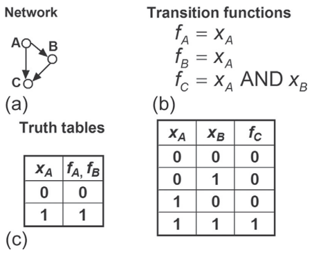

Figura 4.4

[output not shown]

```r
net16 <- loadNetwork("Redes/ejercicio_red_4.4_a_0.txt")
net16
```

```
## Boolean network with 3 genes
##
## Involved genes:
## A B C
##
## Transition functions:
## A = 0
## B = A
## C = A & B
##
## Knocked-out and over-expressed genes:
## A = 0
```

```r
attractors_net16 <- getAttractors(net16)
attractors_net16
```

```
## Attractor 1 is a simple attractor consisting of 1 state(s) and has a basin of 4 state(s):
##
##  |--<--|
##  V     |
##  000   |
##  V     |
##  |-->--|
##
##
## Genes are encoded in the following order: A B C
```

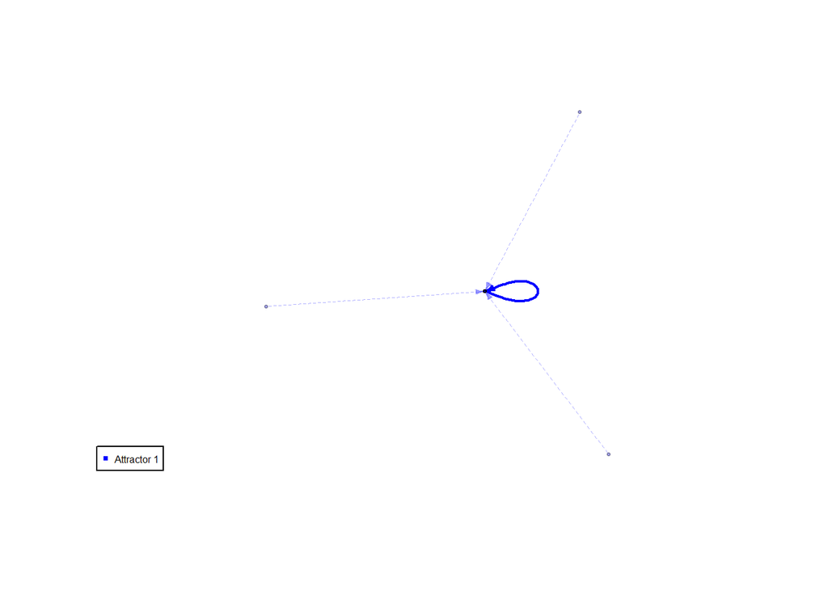

```r
plotStateGraph(attractors_net16)
```

No cambia el estado de atractor

##### Ejercicio 4.8 Figura 4.5 A) AND, A = 1

```
targets, factors
A, 1
B, A
C, B & ! A
```

```r
net17 <- loadNetwork("Redes/ejercicio_red_4.5_a_and_a_1.txt")
net17
```

```
## Boolean network with 3 genes
##
## Involved genes:
## A B C
##
## Transition functions:
## A = 1
## B = A
## C = B & ! A
##
## Knocked-out and over-expressed genes:
## A = 1
```

```r
attractors_net17 <- getAttractors(net17)
attractors_net17
```

```
## Attractor 1 is a simple attractor consisting of 1 state(s) and has a basin of 4 state(s):
##
##  |--<--|
##  V     |
##  110   |
##  V     |
##  |-->--|
##
##
## Genes are encoded in the following order: A B C
```

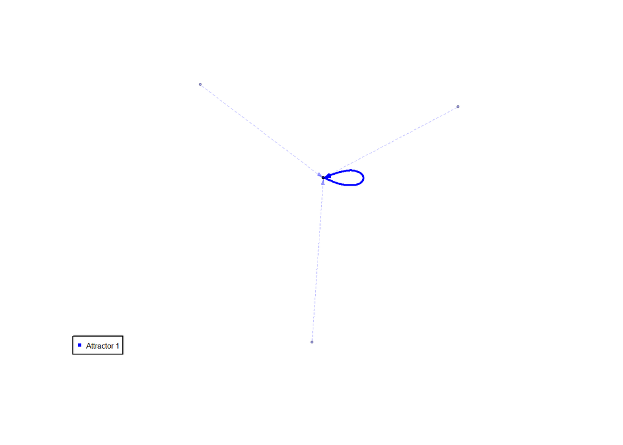

```r
plotStateGraph(attractors_net17)
```

No cambia el estado de atractor

##### Ejercicio 4.8 FIGURA 4.5 A) AND, A = 0

```
targets, factors
A, 0
B, A
C, B & ! A
```

```r
net18 <- loadNetwork("Redes/ejercicio_red_4.5_a_and_a_0.txt")
net18
```

```
## Boolean network with 3 genes
##
## Involved genes:
## A B C
##
## Transition functions:
## A = 0
## B = A
## C = B & ! A
##
## Knocked-out and over-expressed genes:
## A = 0
```

```r
attractors_net18 <- getAttractors(net18)
attractors_net18
```

```
## Attractor 1 is a simple attractor consisting of 1 state(s) and has a basin of 4 state(s):
##
##  |--<--|
##  V     |
##  000   |
##  V     |
##  |-->--|
##
##
## Genes are encoded in the following order: A B C
```

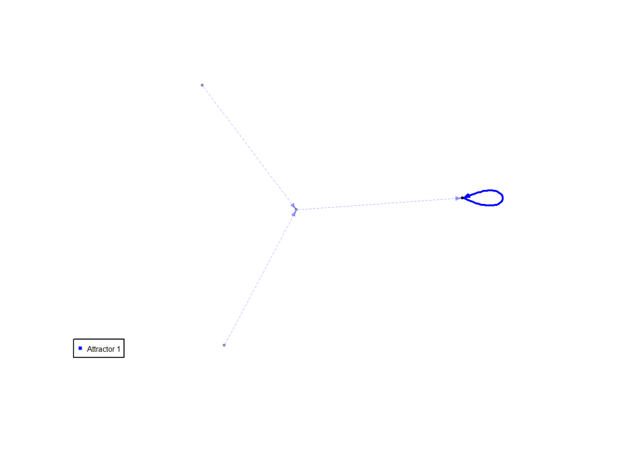

```r
plotStateGraph(attractors_net18)
```

No cambia el estado de atractor

##### Ejercicio 4.8 FIGURA 4.5 A) OR, A = 1

```
targets, factors
A, 1
B, A
C, B | ! A
```

```r
net19 <- loadNetwork("Redes/ejercicio_red_4.5_a_or_a_1.txt")
net19
```

```
## Boolean network with 3 genes
##
## Involved genes:
## A B C
##
## Transition functions:
## A = 1
## B = A
## C = B | ! A
##
## Knocked-out and over-expressed genes:
## A = 1
```

```r
attractors_net19 <- getAttractors(net19)
attractors_net19
```

```
## Attractor 1 is a simple attractor consisting of 1 state(s) and has a basin of 4 state(s):
##
##  |--<--|
##  V     |
##  111   |
##  V     |
##  |-->--|
##
##
## Genes are encoded in the following order: A B C
```

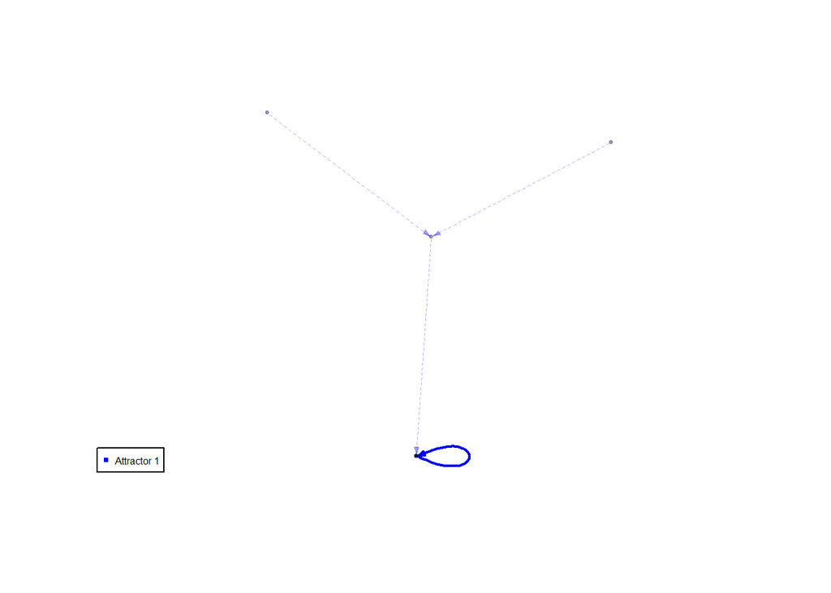

```r
plotStateGraph(attractors_net19)
```

No cambia el estado de atractor

##### Ejercicio 4.8 FIGURA 4.5 A) OR, A = 0

```
targets, factors
A, 0
B, A
C, B | ! A
```

```r
net20 <- loadNetwork("Redes/ejercicio_red_4.5_a_or_a_0.txt")
net20
```

```
## Boolean network with 3 genes
##
## Involved genes:
## A B C
##
## Transition functions:
## A = 0
## B = A
## C = B | ! A
##
## Knocked-out and over-expressed genes:
## A = 0
```

```r
attractors_net20 <- getAttractors(net20)
attractors_net20
```

```
## Attractor 1 is a simple attractor consisting of 1 state(s) and has a basin of 4 state(s):
##
##  |--<--|
##  V     |
##  001   |
##  V     |
##  |-->--|
##
##
## Genes are encoded in the following order: A B C
```

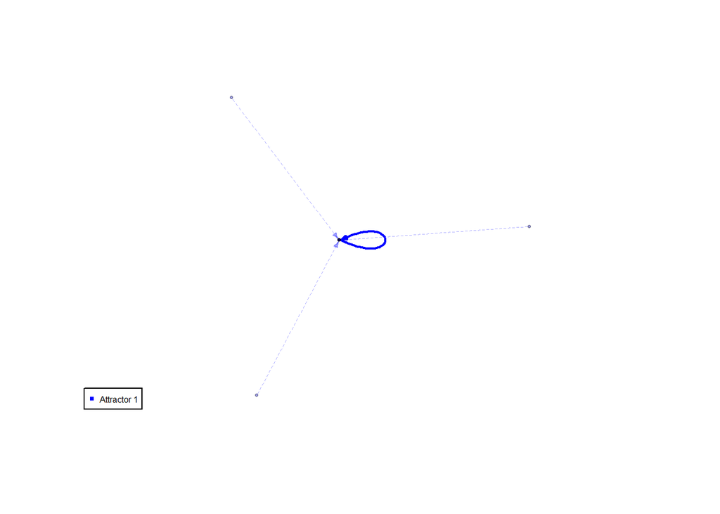

```r
plotStateGraph(attractors_net20)
```

No cambia el estado de atractor

##### Ejercicio 4.8 FIGURA 4.5 B) AND, A = 1

```
targets, factors
A, 1
B, A & !C
C, !B
```

```r
net21 <- loadNetwork("Redes/ejercicio_red_4.5_b_and_a_1.txt")
net21
```

```
## Boolean network with 3 genes
##
## Involved genes:
## A B C
##
## Transition functions:
## A = 1
## B = A & !C
## C = !B
##
## Knocked-out and over-expressed genes:
## A = 1
```

```r
attractors_net21 <- getAttractors(net21)
attractors_net21
```

```
## Attractor 1 is a simple attractor consisting of 1 state(s) and has a basin of 1 state(s):
##
##  |--<--|
##  V     |
##  110   |
##  V     |
##  |-->--|
##
##
## Genes are encoded in the following order: A B C
##
## Attractor 2 is a simple attractor consisting of 1 state(s) and has a basin of 1 state(s):
##
##  |--<--|
##  V     |
##  101   |
##  V     |
##  |-->--|
##
##
## Genes are encoded in the following order: A B C
##
## Attractor 3 is a simple attractor consisting of 2 state(s) and has a basin of 2 state(s):
##
##  |--<--|
##  V     |
##  100   |
##  111   |
##  V     |
##  |-->--|
##
##
## Genes are encoded in the following order: A B C
```

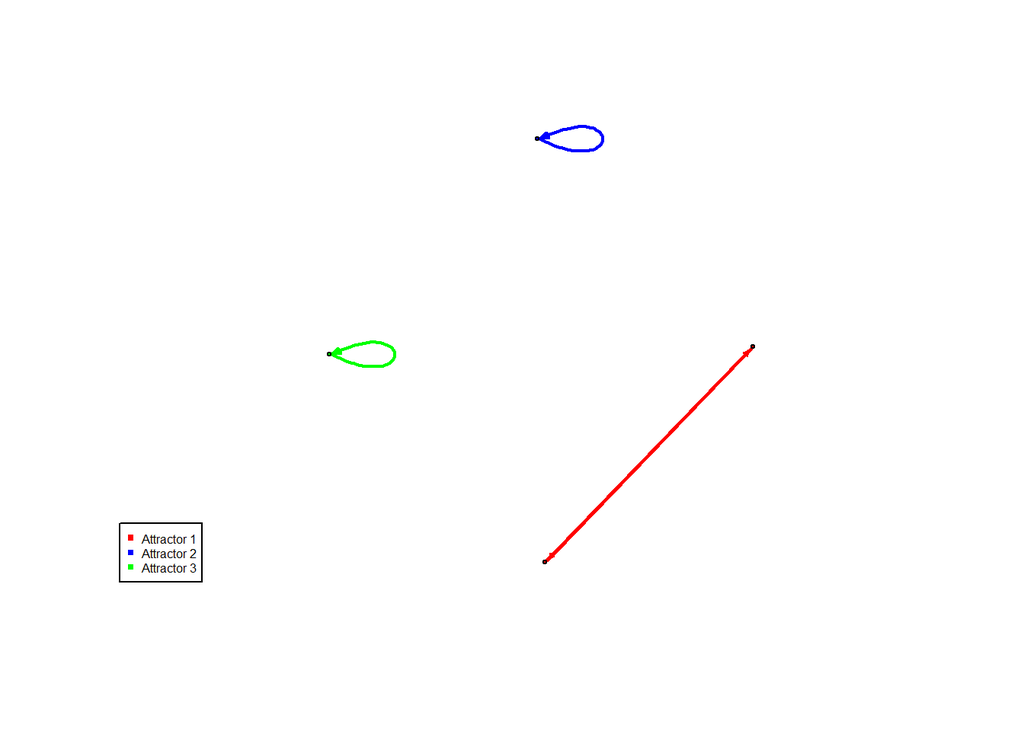

```r
plotStateGraph(attractors_net21)
```

Aparece un nuevo estado de atractor con 2 estados, 100 y 111, aparte de los dos estados de atractor que ya existían.

##### Ejercicio 4.8 FIGURA 4.5 B) AND, A = 0

```
targets, factors
A, 0
B, A & !C
C, !B
```

```r
net22 <- loadNetwork("Redes/ejercicio_red_4.5_b_and_a_0.txt")
net22
```

```
## Boolean network with 3 genes
##
## Involved genes:
## A B C
##
## Transition functions:
## A = 0
## B = A & !C
## C = !B
##
## Knocked-out and over-expressed genes:
## A = 0
```

```r
attractors_net22 <- getAttractors(net22)
attractors_net22
```

```
## Attractor 1 is a simple attractor consisting of 1 state(s) and has a basin of 4 state(s):
##
##  |--<--|
##  V     |
##  001   |
##  V     |
##  |-->--|
##
##
## Genes are encoded in the following order: A B C
```

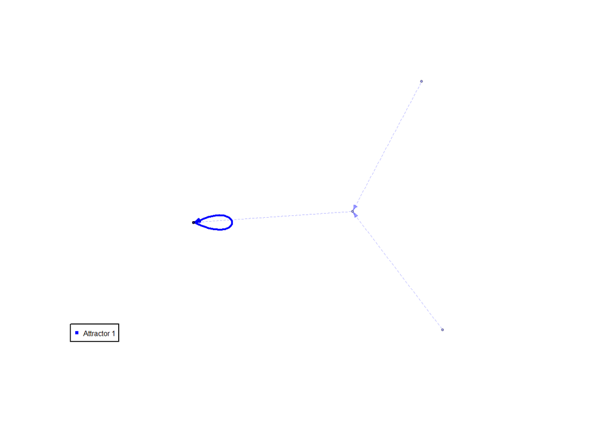

```r
plotStateGraph(attractors_net22)
```

No cambia el estado de atractor

##### Ejercicio 4.8 FIGURA 4.5 B) OR, A = 1

```
targets, factors
A, 1
B, A | !C
C, !B
```

```r
net23 <- loadNetwork("Redes/ejercicio_red_4.5_b_or_a_1.txt")
net23
```

```
## Boolean network with 3 genes
##
## Involved genes:
## A B C
##
## Transition functions:
## A = 1
## B = A | !C
## C = !B
##
## Knocked-out and over-expressed genes:
## A = 1
```

```r
attractors_net23 <- getAttractors(net23)
attractors_net23
```

```
## Attractor 1 is a simple attractor consisting of 1 state(s) and has a basin of 4 state(s):
##
##  |--<--|
##  V     |
##  110   |
##  V     |
##  |-->--|
##
##
## Genes are encoded in the following order: A B C
```

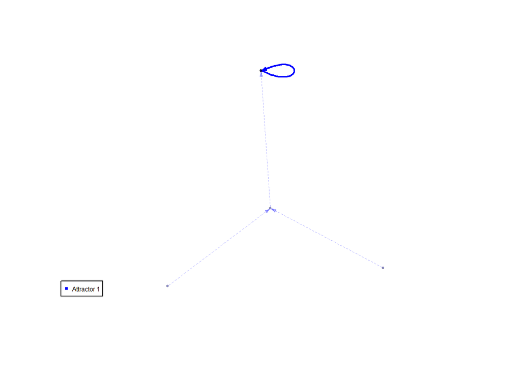

```r
plotStateGraph(attractors_net23)
```

No cambia el estado de atractor

##### Ejercicio 4.8 FIGURA 4.5 B) OR, A = 0

```
targets, factors
A, 0
B, A | !C
C, !B
```

```r
net24 <- loadNetwork("Redes/ejercicio_red_4.5_b_or_a_0.txt")
net24
```

```
## Boolean network with 3 genes
##
## Involved genes:
## A B C
##
## Transition functions:
## A = 0
## B = A | !C
## C = !B
##
## Knocked-out and over-expressed genes:
## A = 0
```

```r
attractors_net24 <- getAttractors(net24)
attractors_net24
```

```
## Attractor 1 is a simple attractor consisting of 1 state(s) and has a basin of 1 state(s):
##
##  |--<--|
##  V     |
##  010   |
##  V     |
##  |-->--|
##
##
## Genes are encoded in the following order: A B C
##
## Attractor 2 is a simple attractor consisting of 1 state(s) and has a basin of 1 state(s):
##
##  |--<--|
##  V     |
##  001   |
##  V     |
##  |-->--|
##
##
## Genes are encoded in the following order: A B C
##
## Attractor 3 is a simple attractor consisting of 2 state(s) and has a basin of 2 state(s):
##
##  |--<--|
##  V     |
##  000   |
##  011   |
##  V     |
##  |-->--|
##
##
## Genes are encoded in the following order: A B C
```

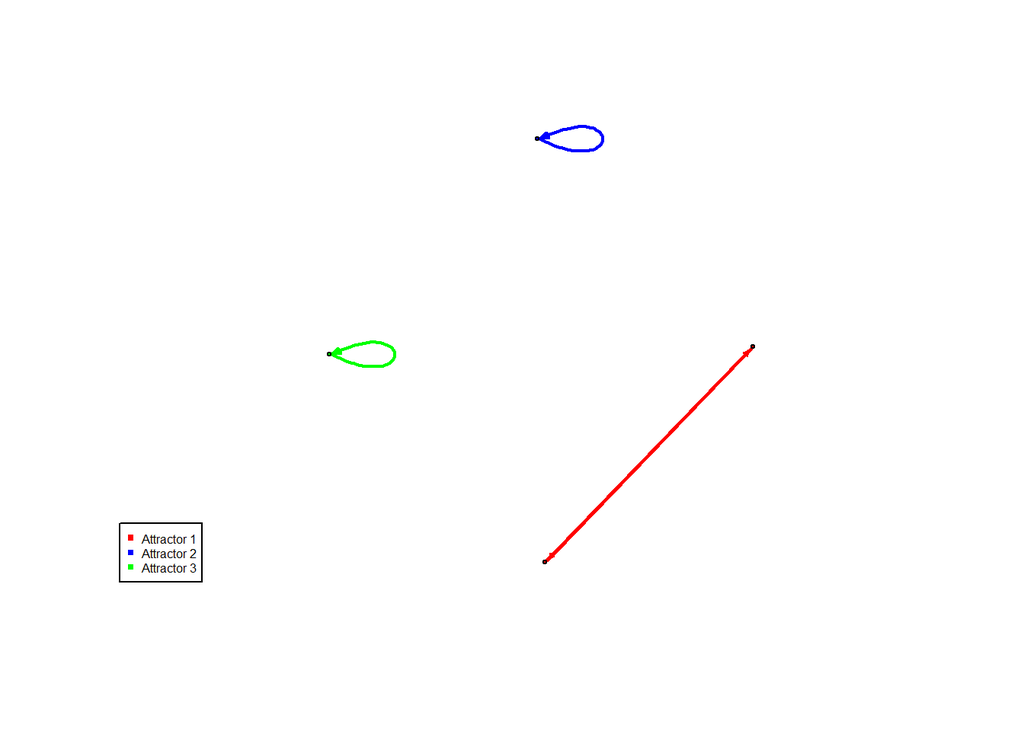

```r
plotStateGraph(attractors_net24)
```

Aparece un nuevo estado de atractor con 2 estados, 000 y 011, aparte de los dos estados de atractor que ya existían.

### Ejercicio 4.10

Considere la red en la Figura 4.7. Determine el gráfico de transición de estado de la red, utilizando primero la actualización síncrona y luego la actualización asíncrona general. Para el caso xI = 0, compare sus gráficos con los de la figura 4.7.

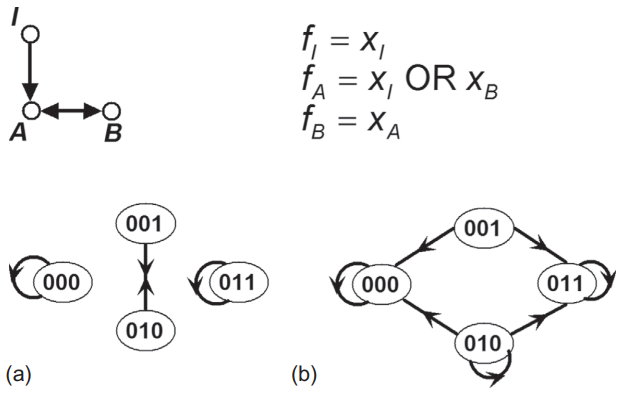

Figura 4.7

##### Sincrónica & A = 1

```
targets, factors
I, 1
A, I | B
B, A
```

```r
net25 <- loadNetwork("Redes/ejercicio_red_4.7_i_1.txt")
net25
```

```
## Boolean network with 3 genes
##
## Involved genes:
## I A B
##
## Transition functions:
## I = 1
## A = I | B
## B = A
##
## Knocked-out and over-expressed genes:
## I = 1
```

```r
attractors_net25 <- getAttractors(net25)
attractors_net25
```

```
## Attractor 1 is a simple attractor consisting of 1 state(s) and has a basin of 4 state(s):
##
##  |--<--|
##  V     |
##  111   |
##  V     |
##  |-->--|
##
##
## Genes are encoded in the following order: I A B
```

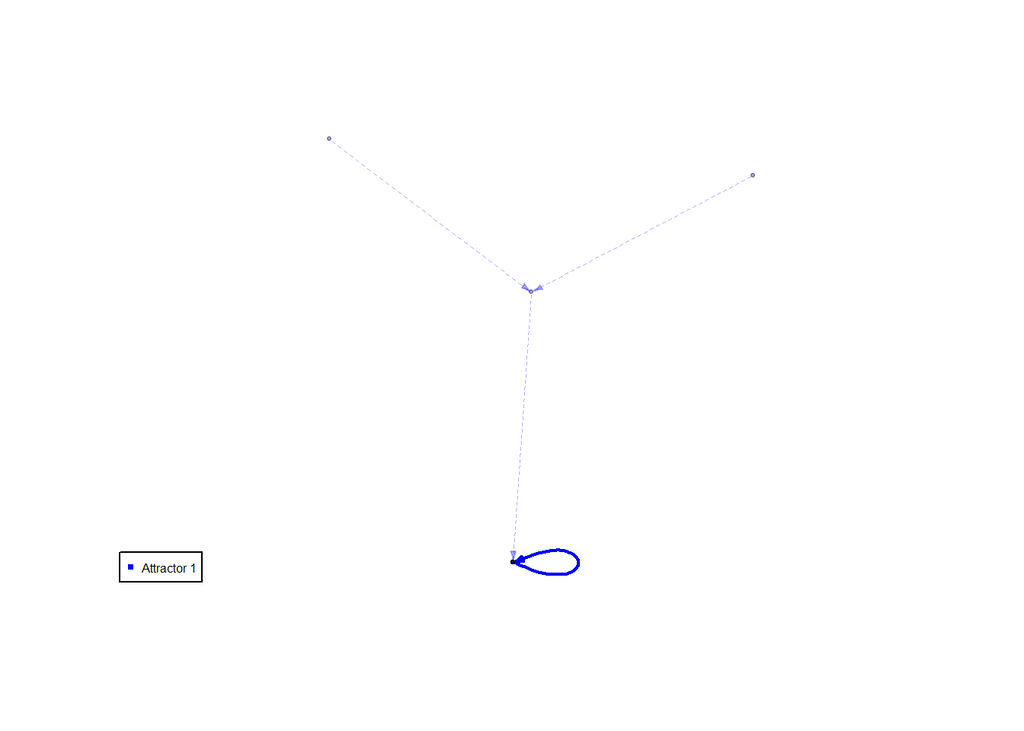

```r
plotStateGraph(attractors_net25)
```

##### Sincrónica & A = 0

```
targets, factors
I, 0
A, I | B
B, A
```

```r
net26 <- loadNetwork("Redes/ejercicio_red_4.7_i_0.txt")
net26
```

```
## Boolean network with 3 genes
##
## Involved genes:
## I A B
##
## Transition functions:
## I = 0
## A = I | B
## B = A
##
## Knocked-out and over-expressed genes:
## I = 0
```

```r
attractors_net26 <- getAttractors(net26)
attractors_net26
```

```
## Attractor 1 is a simple attractor consisting of 1 state(s) and has a basin of 1 state(s):
##
##  |--<--|
##  V     |
##  000   |
##  V     |
##  |-->--|
##
##
## Genes are encoded in the following order: I A B
##
## Attractor 2 is a simple attractor consisting of 1 state(s) and has a basin of 1 state(s):
##
##  |--<--|
##  V     |
##  011   |
##  V     |
##  |-->--|
##
##
## Genes are encoded in the following order: I A B
##
## Attractor 3 is a simple attractor consisting of 2 state(s) and has a basin of 2 state(s):
##
##  |--<--|
##  V     |
##  010   |
##  001   |
##  V     |
##  |-->--|
##
##
## Genes are encoded in the following order: I A B
```

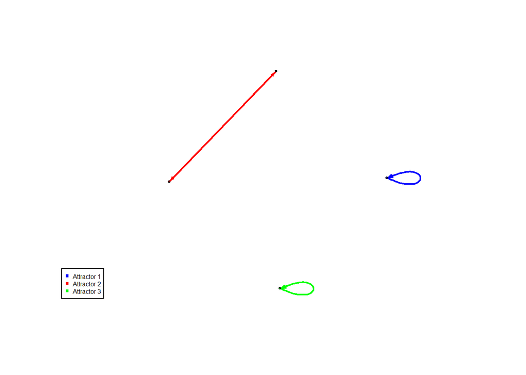

```r
plotStateGraph(attractors_net26)
```

##### Asincrónica & A = 1

```
targets, factors
I, 1
A, I | B
B, A
```

```r
net27 <- loadNetwork("Redes/ejercicio_red_4.7_i_1.txt")
net27
```

```
## Boolean network with 3 genes
##
## Involved genes:
## I A B
##
## Transition functions:
## I = 1
## A = I | B
## B = A
##
## Knocked-out and over-expressed genes:
## I = 1
```

```r
attractors_net27 <- getAttractors(net27, type = "asynchronous", startStates=4)
attractors_net27
```

```
## Attractor 1 is a simple attractor consisting of 1 state(s):
##
##  |--<--|
##  V     |
##  111   |
##  V     |
##  |-->--|
##
##
## Genes are encoded in the following order: I A B
```

```r
BoolNet::plotAttractors(attractors_net27, mode="graph")
```

[output not shown]

##### Asincrónica & A = 0

```
targets, factors
I, 0
A, I | B
B, A
```

```r
net28 <- loadNetwork("Redes/ejercicio_red_4.7_i_0.txt")
net28
```

```
## Boolean network with 3 genes
##
## Involved genes:
## I A B
##
## Transition functions:
## I = 0
## A = I | B
## B = A
##
## Knocked-out and over-expressed genes:
## I = 0
```

```r
attractors_net28 <- getAttractors(net28, type = "asynchronous", startStates=4)
attractors_net28
```

```
## Attractor 1 is a simple attractor consisting of 1 state(s):
##
##  |--<--|
##  V     |
##  011   |
##  V     |
##  |-->--|
##
##
## Genes are encoded in the following order: I A B
##
## Attractor 2 is a simple attractor consisting of 1 state(s):
##
##  |--<--|
##  V     |
##  000   |
##  V     |
##  |-->--|
##
##
## Genes are encoded in the following order: I A B
```

```r
BoolNet::plotAttractors(attractors_net28, mode="graph")
```

[output not shown]